# Data Visualization

Michael Kistner

May 16, 2022

# Introduction

The final portion of our data cleaning workshop will cover the basics of data visualization using **ggplot2*, the most powerful and commonly used data visualization engine for R. While data visualization plays a larger role in steps 4 and 5 of the research process (Analyze Data; Share Findings), it can also be an important element of data cleaning and transformation as well. Plotting your data can allow you to discover outliers that should be investigated further, skewed distributions that should be logged or altered, clusters or patterns that indicate a grouping that you haven’t yet considered. In reality, the linear process detailed in the Project and Data Organization section tends to be more circular and iterative. Frequently analysis and sharing will lead to further necessary data cleaning and transformation.

One more time, let’s load the **tidyverse** package up and dive in.

```r
library(tidyverse)
```

# Visualizing distributions of single variables

One of the first steps in understanding the data you have collected is visualizing the distribution of key variables. What do the key data look like? To consider an example, let’s load the `house_tweets` dataframe.

```r
load("Data/House Tweets.Rda")
```

A natural first question is to determine whether members of Congres are tweeting in roughly equal amounts, or if some are more prodigious social media users than others.

```r
graphing_data <- group_by(house_tweets, name) %>%
  summarize(n_tweets = n())

graphing_data %>%
  arrange(desc(n_tweets))
```

```
## # A tibble: 392 x 2
##    name                       n_tweets
##    <chr>                         <int>
##  1 ROY, Charles                  12550
##  2 LONG, Billy                   11286
##  3 EVANS, Dwight                  6787
##  4 GONZÁLEZ-CÓLON, Jenniffer      6526
##  5 BIGGS, Andrew S.               6430
##  6 MALONEY, Carolyn Bosher        5455
##  7 CASTRO, Joaquin                5403
##  8 BEYER, Donald Sternoff Jr.     5318
##  9 JAYAPAL, Pramila               5229
## 10 GALLEGO, Ruben                 4451
## # ... with 382 more rows
```

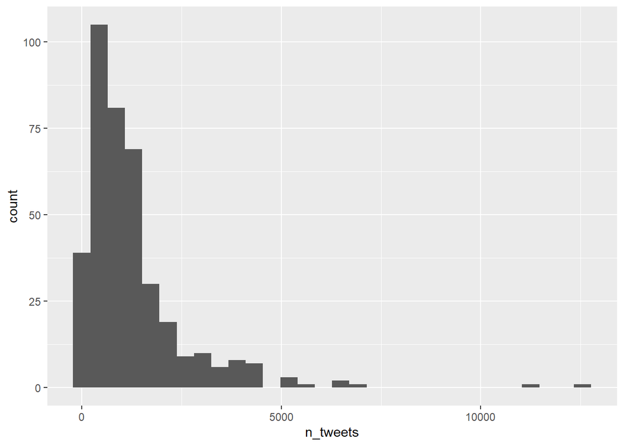

```r
ggplot(graphing_data,
       aes(x = n_tweets)) +
  geom_histogram()
```

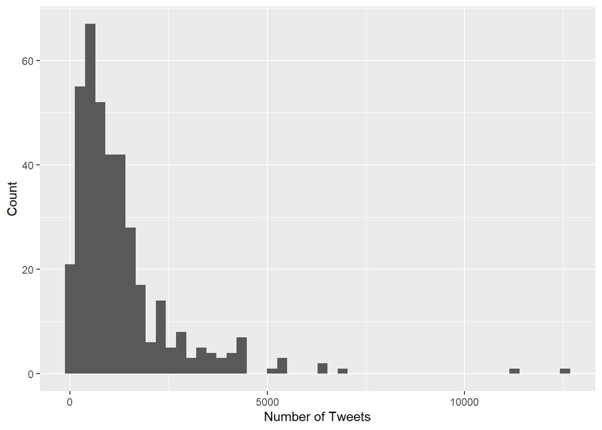

```r
ggplot(graphing_data,
       aes(x = n_tweets)) +
  geom_histogram(bins = 50) +
  labs(x = "Number of Tweets",
       y = "Count")
```

# Visualizing relationships between multiple variables